# YBR196C-A Mutant Transcriptome

Saurin Parikh

06/03/2020

# Introduction

## YBR196C-A

- “Putative protein of unknown function” - [Saccharomyces Genome Database (SGD)](https://www.yeastgenome.org/locus/S000028534)
- 150 base pair long
- Artificial overexpression of this gene using a plasmid based system led to increased growth in 3/5 conditions tested<sup>#</sup>
- 3D structure prediction shows that it contains a transmembrane domain<sup>#</sup>
- In vivo analysis for subcellular localization shows that it localizes to the endoplasmic reticulum membrane<sup>#</sup>

# = [Vakirlis et. al. 2020](https://doi.org/10.1038/s41467-020-14500-z)

## RNASeq Data

- 4 strains:
  - WT - wild type
  - KAN - traditional KanMX deletion of YBR196C-A
  - CRISPY - CRISPR deletion of YBR196C-A
  - CRISPY.ATG - CRISPR start codon mutation of YBR196C-A
- All strains are BY4742 background with empty expression vector (pBY011)
- Strains grown in liquid media with galactose for ~24 hours and then liquid media with casamino acid + galactose for ~24 hours
- 3 samples (cellular material) per strain sent for strand specific pair-end RNA sequencing (Genewiz Order Number: 30-345558359)
- Library preparation was done using rRNA reduction

# Raw Read Quality Check

## Running FastQC on Raw Data

```bash
cd ~/RNASeq/FastQC
for fn in ~/RNASeq/YBR/fastq_files/rawdata/*.fastq;
do
samp=`basename ${fn}`
dir=`dirname ${fn}`
mkdir -p ${dir}/qc

echo "QC-ing sample ${samp}"
./fastqc ${dir}/${samp} -o ${dir}/qc/ > /dev/null 2>&1
done
cd ~/R/Projects/rnaseek
```

## Raw Data QC Results

| sample | module | status | tot.seq | seq.length | pct.gc | pct.dup |
| --- | --- | --- | --- | --- | --- | --- |
| ARC-NGS-1-1_R1_001 | Basic Statistics | PASS | 36467184 | 150 | 42 | 87.34 |
| ARC-NGS-1-1_R2_001 | Basic Statistics | PASS | 36467184 | 150 | 42 | 79.71 |
| ARC-NGS-1-2_R1_001 | Basic Statistics | PASS | 35676680 | 150 | 42 | 87.15 |
| ARC-NGS-1-2_R2_001 | Basic Statistics | PASS | 35676680 | 150 | 42 | 79.64 |
| ARC-NGS-1-3_R1_001 | Basic Statistics | PASS | 38864290 | 150 | 42 | 89.86 |
| ARC-NGS-1-3_R2_001 | Basic Statistics | PASS | 38864290 | 150 | 42 | 82.51 |
| ARC-NGS-2-1_R1_001 | Basic Statistics | PASS | 36087647 | 150 | 42 | 86.79 |
| ARC-NGS-2-1_R2_001 | Basic Statistics | PASS | 36087647 | 150 | 42 | 79.96 |
| ARC-NGS-2-2_R1_001 | Basic Statistics | PASS | 35591917 | 150 | 42 | 87.05 |
| ARC-NGS-2-2_R2_001 | Basic Statistics | PASS | 35591917 | 150 | 42 | 80.66 |

[output cut: 14 more lines]

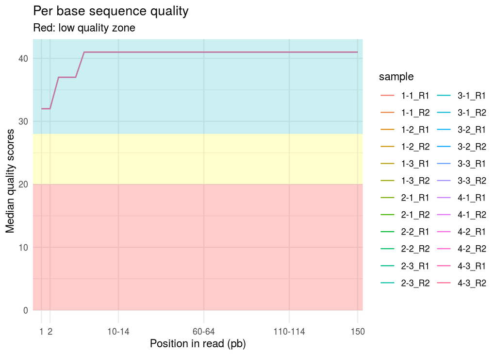

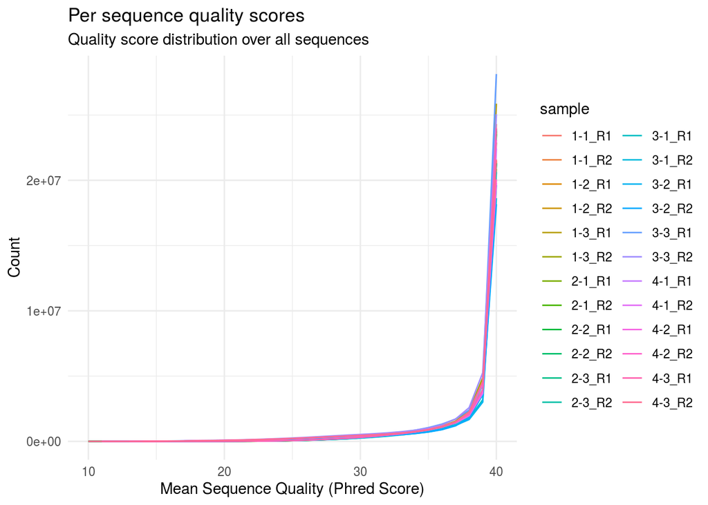

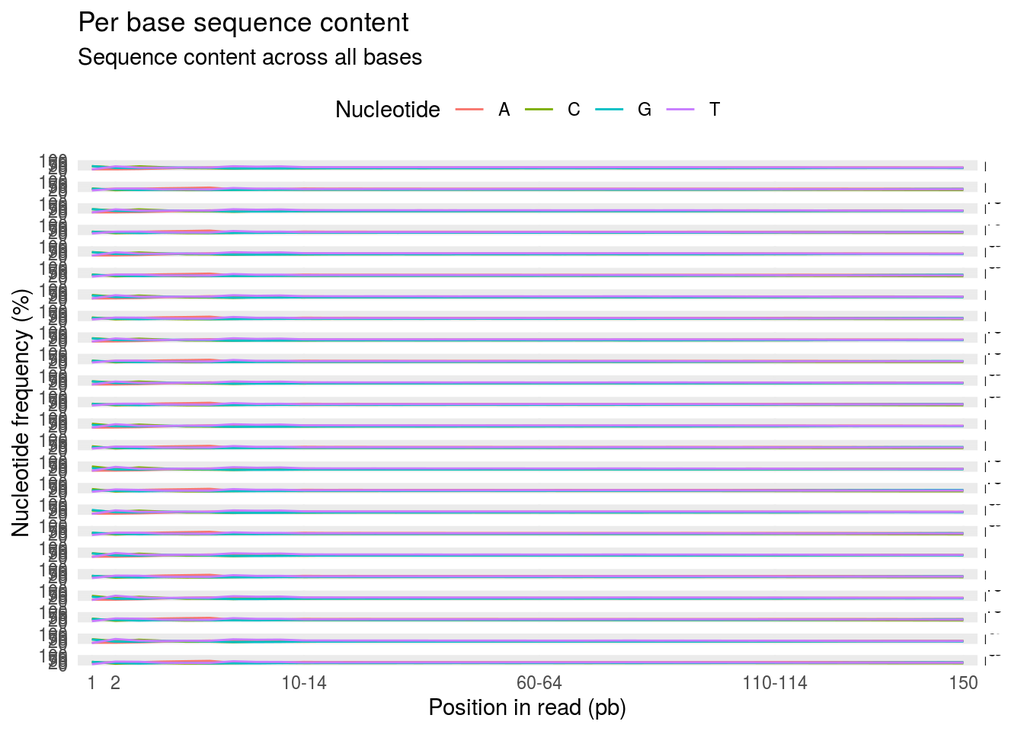

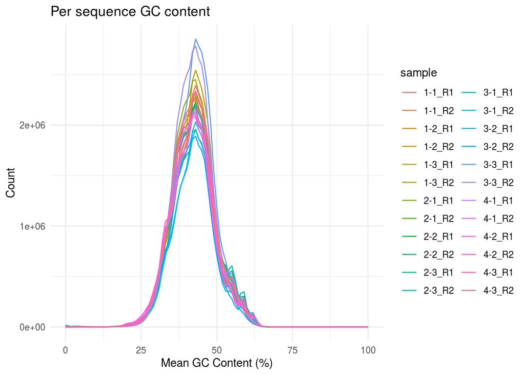

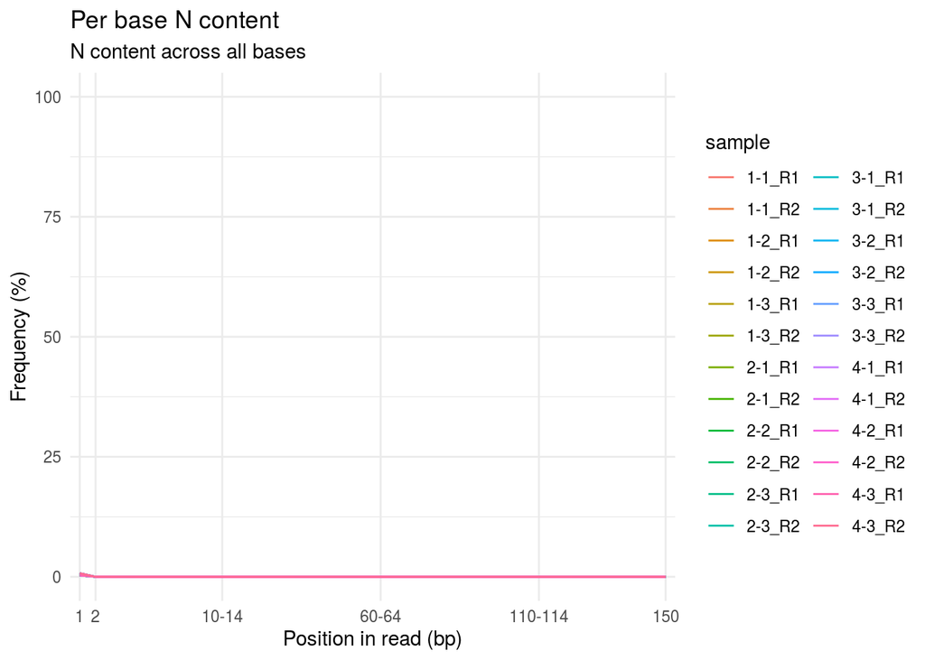

[figure not shown]

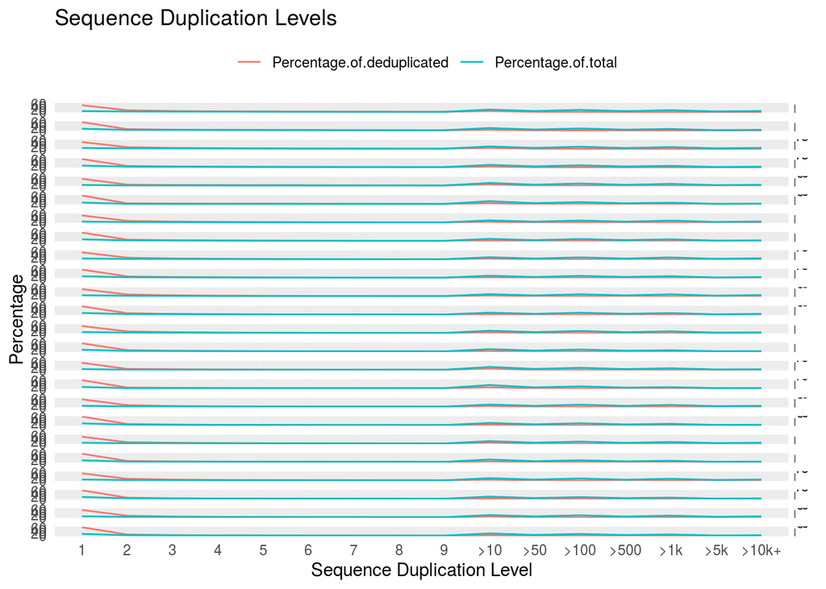

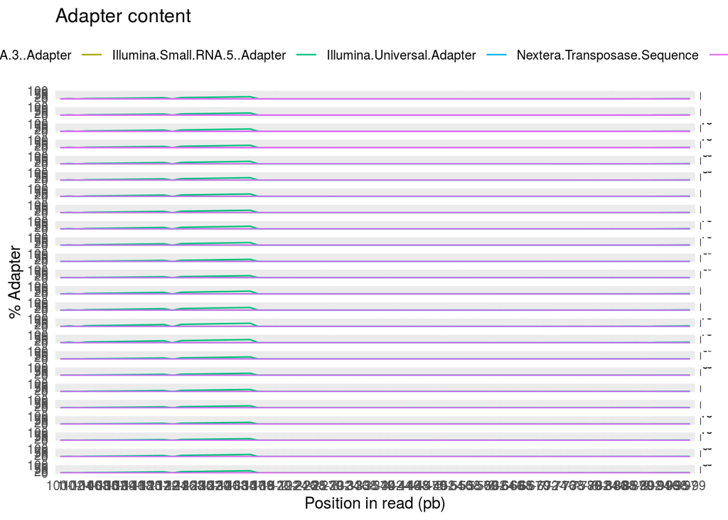

# Trimming RAW data

I chose to:

- crop the 20 bps from the front of the reads - based on the sequence quality results
- limit the cropped reads to 80 bps in order to trim the adapters at the 3-prime end

More information on illumina adapter trimming can be found [here](https://support.illumina.com/bulletins/2016/04/adapter-trimming-why-are-adapter-sequences-trimmed-from-only-the--ends-of-reads.html).

```bash
cd ~/RNASeq/Trimmomatic
for fn in ~/RNASeq/YBR/fastq_files/rawdata/*.fastq;
do
samp=`basename ${fn}`
dir=`dirname ${fn}`
dir2=`dirname ${dir}`
mkdir -p ${dir2}/trimmed1

echo "Trimming sample ${samp}"
java -jar ~/RNASeq/Trimmomatic/trimmomatic-0.39.jar SE -threads 12 \
         ${dir}/${samp} \
         ${dir2}/trimmed1/${samp:0:-6}.trimmed.fastq \
         HEADCROP:20 \
         CROP:80 \
         MINLEN:20 > /dev/null 2>&1
done
cd ~/R/Projects/rnaseek
```

## Quality Check the Trimmed Resuls

| sample | module | status | tot.seq | seq.length | pct.gc | pct.dup |
| --- | --- | --- | --- | --- | --- | --- |
| ARC-NGS-1-1_R1_001.trimmed | Basic Statistics | PASS | 36467184 | 80 | 41 | 88.65 |
| ARC-NGS-1-1_R2_001.trimmed | Basic Statistics | PASS | 36467184 | 80 | 41 | 79.75 |
| ARC-NGS-1-2_R1_001.trimmed | Basic Statistics | PASS | 35676680 | 80 | 41 | 88.52 |
| ARC-NGS-1-2_R2_001.trimmed | Basic Statistics | PASS | 35676680 | 80 | 41 | 79.84 |
| ARC-NGS-1-3_R1_001.trimmed | Basic Statistics | PASS | 38864290 | 80 | 41 | 90.46 |
| ARC-NGS-1-3_R2_001.trimmed | Basic Statistics | PASS | 38864290 | 80 | 41 | 82.65 |
| ARC-NGS-2-1_R1_001.trimmed | Basic Statistics | PASS | 36087647 | 80 | 41 | 88.22 |
| ARC-NGS-2-1_R2_001.trimmed | Basic Statistics | PASS | 36087647 | 80 | 41 | 80.08 |
| ARC-NGS-2-2_R1_001.trimmed | Basic Statistics | PASS | 35591917 | 80 | 41 | 88.28 |
| ARC-NGS-2-2_R2_001.trimmed | Basic Statistics | PASS | 35591917 | 80 | 41 | 80.66 |

[output cut: 14 more lines]

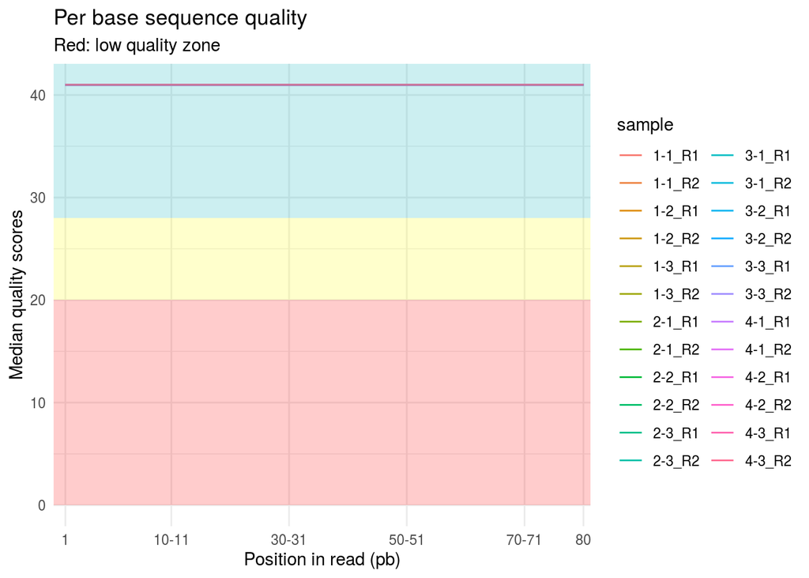

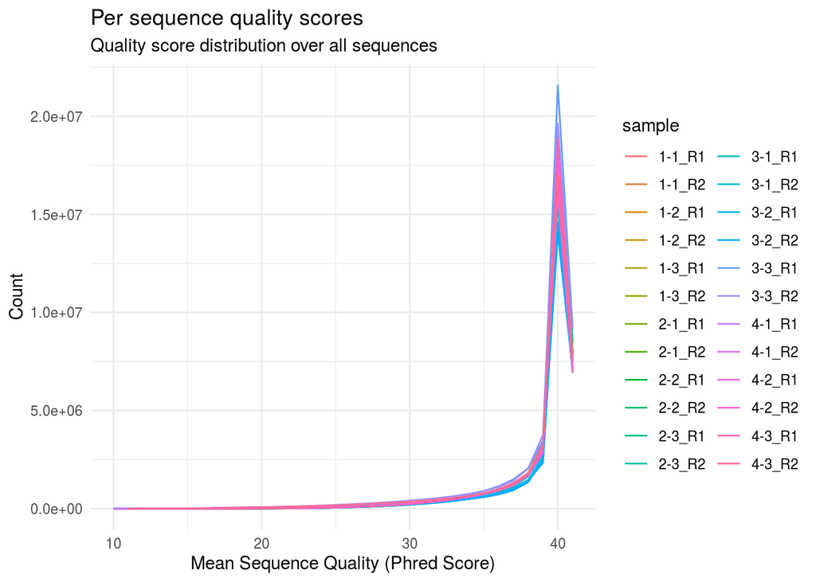

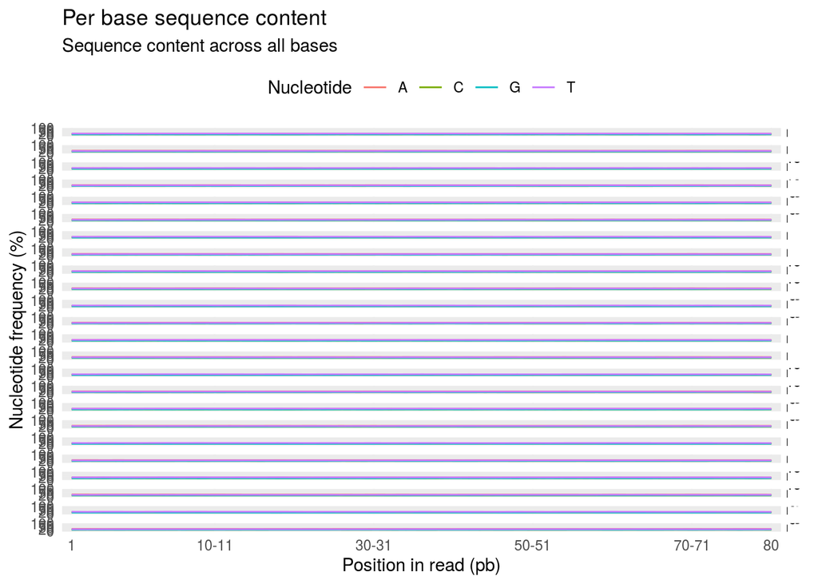

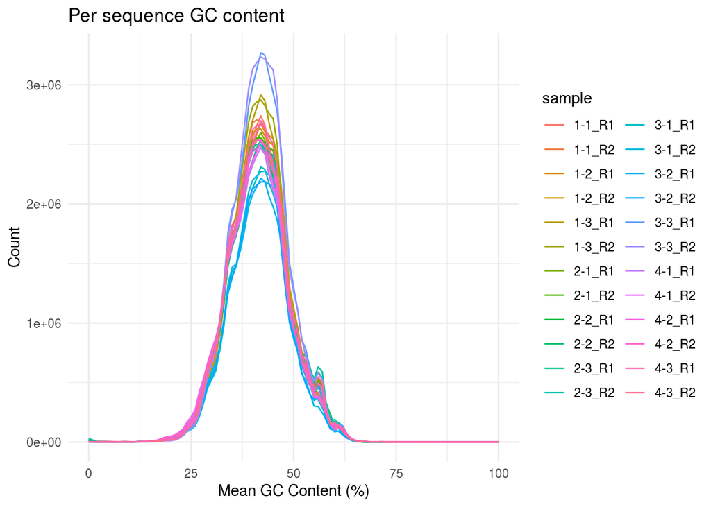

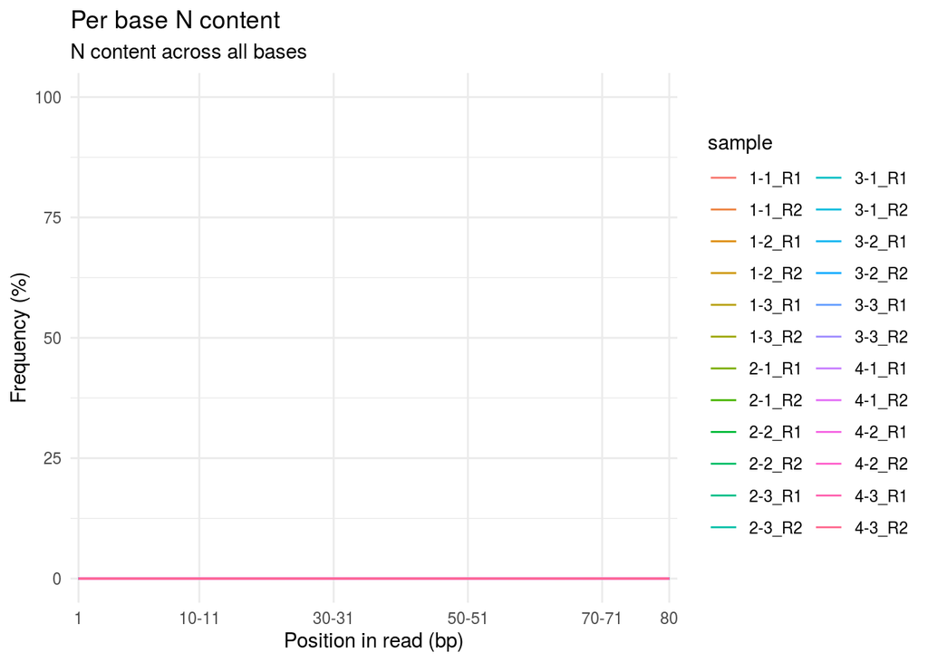

[figure not shown]

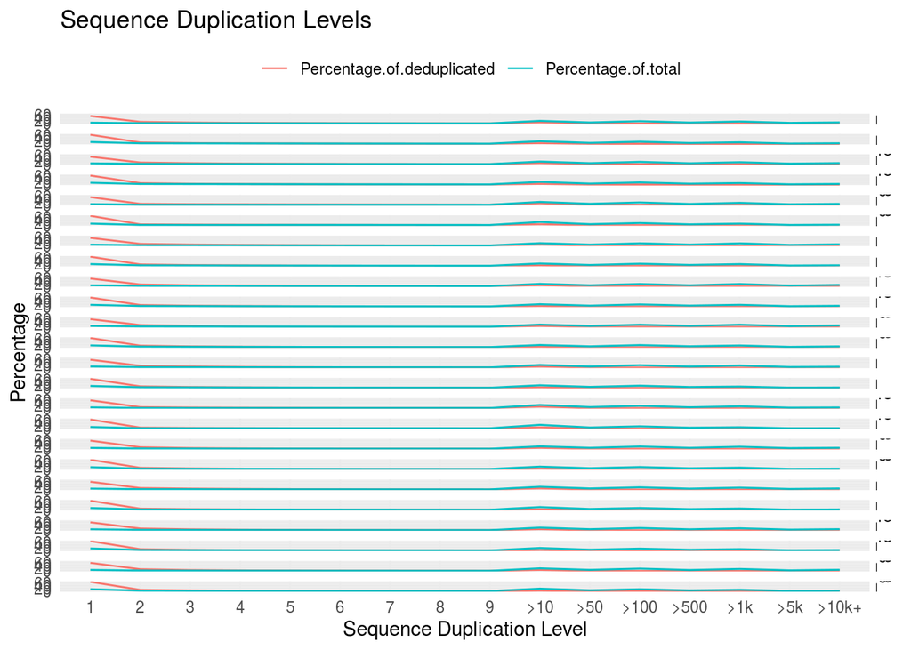

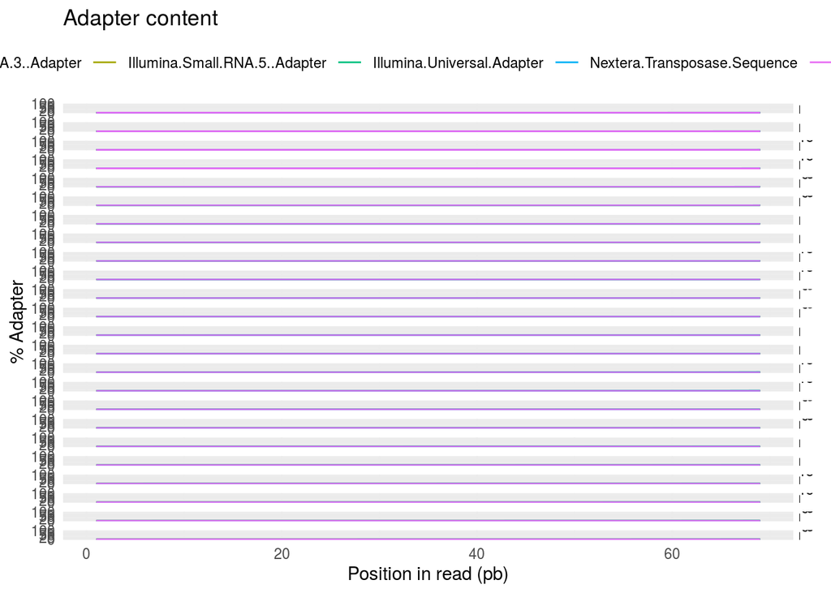

## Overrepresented Sequences (ORS)

Overrepresented sequences (ORS) were coming up as 'No Hit' on FastQC results. I saved all the ORS as a fasta file which was then blasted in [SGD](https://www.yeastgenome.org/blast-sgd). The hits included ncRNAs and transposable elements.

```
## [1] "There are 44 overrepresented sequences in total."
```

Below is a screenshot from the result:

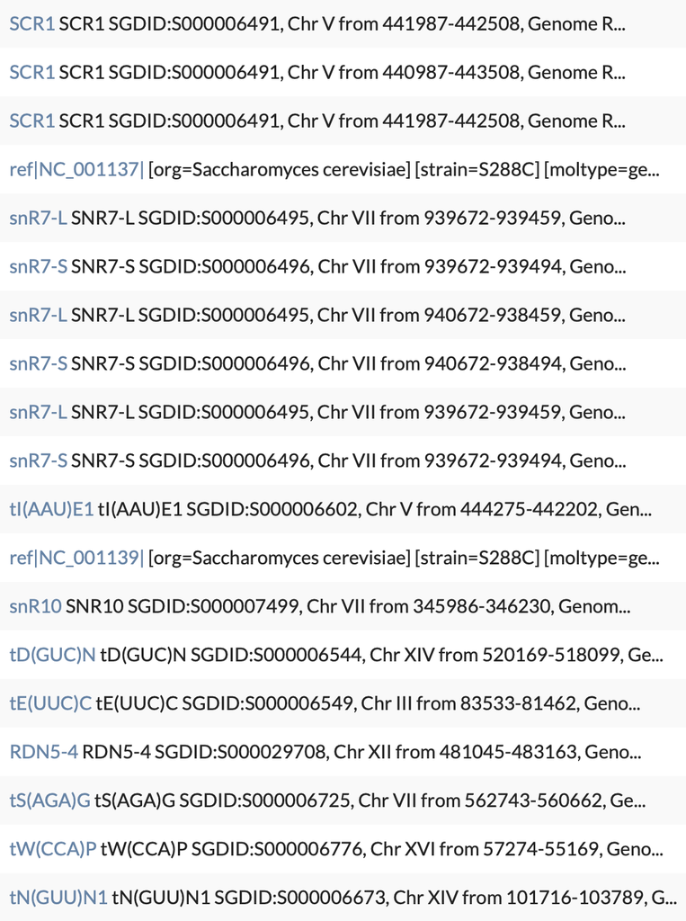

Based on this result I decided to use a genome annotation file that includes all features for aligning the reads. Once aligned I will focusing on coding sequences for my downstream analysis.

# Using STAR for aligning reads

## Generating genome index

Downloaded the R64-1-1 genome built and feature annotation from [Ensembl](https://useast.ensembl.org/Saccharomyces_cerevisiae/Info/Index).

```bash
mkdir -p ~/RNASeq/YBR/STAR_index

~/RNASeq/STAR/bin/Linux_x86_64/STAR \
        --runThreadN 8 \
        --runMode genomeGenerate \
        --genomeDir ~/RNASeq/YBR/STAR_index \
        --genomeFastaFiles ~/RNASeq/YBR/genome.fa \
        --sjdbGTFfile ~/RNASeq/YBR/scer.gtf \
        --sjdbOverhang 79 > /dev/null 2>&1
```

## Aligning and counting reads

```bash
rm foo.bar
for fn in ~/RNASeq/YBR/fastq_files/trimmed1/*.fastq;
do
samp=`basename ${fn}`
dir=`dirname ${fn}`
grep -qxF "${samp:0:11}" foo.bar || echo "${samp:0:11}" >> foo.bar
done
```

```bash
input="foo.bar"
dir=~/RNASeq/YBR/fastq_files/trimmed1
mkdir -p ${dir}/quant_star

while IFS= read -r samp
do
  echo "Processing sample ${samp}"
  ls $dir/$samp*

  ~/RNASeq/STAR/bin/Linux_x86_64/STAR \
          --runThreadN 8 \
          --runMode alignReads \
          --outFilterMultimapNmax 1 \
          --outSAMtype BAM Unsorted SortedByCoordinate \
          --readFilesIn ${dir}/${samp}_R1_001.trimmed.fastq ${dir}/${samp}_R2_001.trimmed.fastq \
          --quantMode GeneCounts \
          --twopassMode Basic \
          --outFileNamePrefix ${dir}/quant_star/${samp}_quant \
          --genomeDir ~/RNASeq/YBR/STAR_index \
          --sjdbGTFfile ~/RNASeq/YBR/scer.gtf > /dev/null 2>&1
done < "$input"
```

STAR log for one of the file:

```bash
cat ~/RNASeq/YBR/fastq_files/trimmed1/quant_star/ARC-NGS-1-1_quantLog.final.out
```

```
##                                  Started job on |    Jun 02 11:51:14
##                              Started mapping on |    Jun 02 12:06:13
##                                     Finished on |    Jun 02 12:21:57
##        Mapping speed, Million of reads per hour |    139.07
##
##                           Number of input reads |    36467184
##                       Average input read length |    160
##                                     UNIQUE READS:
##                    Uniquely mapped reads number |    24517764
##                         Uniquely mapped reads % |    67.23%
##                           Average mapped length |    159.77
##                        Number of splices: Total |    547168
##             Number of splices: Annotated (sjdb) |    526042
##                        Number of splices: GT/AG |    474864
##                        Number of splices: GC/AG |    11976
##                        Number of splices: AT/AC |    9138
##                Number of splices: Non-canonical |    51190
##                       Mismatch rate per base, % |    0.26%
##                          Deletion rate per base |    0.00%
##                         Deletion average length |    1.30
##                         Insertion rate per base |    0.00%
##                        Insertion average length |    1.09
##                              MULTI-MAPPING READS:
##         Number of reads mapped to multiple loci |    0
##              % of reads mapped to multiple loci |    0.00%
##         Number of reads mapped to too many loci |    6398213
##              % of reads mapped to too many loci |    17.55%
##                                   UNMAPPED READS:
##   Number of reads unmapped: too many mismatches |    0
##        % of reads unmapped: too many mismatches |    0.00%
##             Number of reads unmapped: too short |    5512045
##                  % of reads unmapped: too short |    15.12%
##                 Number of reads unmapped: other |    39162
##                      % of reads unmapped: other |    0.11%
##                                   CHIMERIC READS:
##                        Number of chimeric reads |    0
##                             % of chimeric reads |    0.00%
```

Multimapping threshold was set to 1.

# Generating Read Counts

I used featureCounts to generate read counts from the STAR bam files.

|  | WT_1 | WT_2 | WT_3 | KAN_1 | KAN_2 | KAN_3 | CRISPY_1 | CRISPY_2 | CRISPY_3 | CRISPY-ATG_1 | CRISPY-ATG_2 | CRISPY-ATG_3 |
| --- | --- | --- | --- | --- | --- | --- | --- | --- | --- | --- | --- | --- |
| YBR196C | 39670 | 38929 | 43689 | 3291 | 2832 | 3170 | 72086 | 59110 | 102042 | 28929 | 30904 | 32627 |
| YBR196C-A | 27 | 36 | 18 | 0 | 0 | 0 | 0 | 0 | 0 | 37 | 34 | 31 |

All KAN and CRISPY samples have 0 reads for YBR196C-A as expected.

## Pre-filtering

```
## [1] "There are 6348 genes with more than 10 reads in total."
```

```
## [1] "There are 5948 genes with more than 10 reads/sample."
```

I first reduce list to just include coding sequences corresponding to Ensembl gene predictions using fasta file from Ensembl. I also did this using the orf_coding_all.fasta [file from SGD](http://sgd-archive.yeastgenome.org/sequence/S288C_reference/orf_dna/orf_coding_all.fasta.gz) to include all verified, uncharacterized, dubious and transposable element ORFs. This didn't change the downstream results.

I then perform a minimal pre-filtering to keep ORFs that have at least 10 reads in total.

Note that more strict filtering to increase power is automatically applied via independent filtering on the mean of normalized counts within the DESeq results function.

## Pearson correlation of the raw read counts

|  | WT_1 | WT_2 | WT_3 | KAN_1 | KAN_2 | KAN_3 | CRISPY_1 | CRISPY_2 | CRISPY_3 | CRISPY.ATG_1 | CRISPY.ATG_2 | CRISPY.ATG_3 |
| --- | --- | --- | --- | --- | --- | --- | --- | --- | --- | --- | --- | --- |
| WT_1 | 1.0000000 | 0.9995794 | 0.9972612 | 0.9380939 | 0.9363122 | 0.9330240 | 0.9709400 | 0.9785790 | 0.9762816 | 0.9515659 | 0.9485557 | 0.9517585 |
| WT_2 | 0.9995794 | 1.0000000 | 0.9983874 | 0.9436934 | 0.9422539 | 0.9387032 | 0.9754564 | 0.9818398 | 0.9798906 | 0.9506043 | 0.9475580 | 0.9513097 |
| WT_3 | 0.9972612 | 0.9983874 | 1.0000000 | 0.9464116 | 0.9451835 | 0.9393745 | 0.9814441 | 0.9847637 | 0.9855503 | 0.9471954 | 0.9438903 | 0.9505313 |
| KAN_1 | 0.9380939 | 0.9436934 | 0.9464116 | 1.0000000 | 0.9994901 | 0.9980850 | 0.9665490 | 0.9627295 | 0.9619178 | 0.9136210 | 0.9113580 | 0.9166793 |
| KAN_2 | 0.9363122 | 0.9422539 | 0.9451835 | 0.9994901 | 1.0000000 | 0.9981830 | 0.9665410 | 0.9617046 | 0.9614635 | 0.9109521 | 0.9083809 | 0.9143144 |
| KAN_3 | 0.9330240 | 0.9387032 | 0.9393745 | 0.9980850 | 0.9981830 | 1.0000000 | 0.9593313 | 0.9584205 | 0.9540558 | 0.9096574 | 0.9079432 | 0.9102153 |
| CRISPY_1 | 0.9709400 | 0.9754564 | 0.9814441 | 0.9665490 | 0.9665410 | 0.9593313 | 1.0000000 | 0.9945869 | 0.9971923 | 0.9331029 | 0.9303840 | 0.9408097 |
| CRISPY_2 | 0.9785790 | 0.9818398 | 0.9847637 | 0.9627295 | 0.9617046 | 0.9584205 | 0.9945869 | 1.0000000 | 0.9937962 | 0.9489581 | 0.9481143 | 0.9522479 |
| CRISPY_3 | 0.9762816 | 0.9798906 | 0.9855503 | 0.9619178 | 0.9614635 | 0.9540558 | 0.9971923 | 0.9937962 | 1.0000000 | 0.9421783 | 0.9388832 | 0.9496085 |
| CRISPY-ATG_1 | 0.9515659 | 0.9506043 | 0.9471954 | 0.9136210 | 0.9109521 | 0.9096574 | 0.9331029 | 0.9489581 | 0.9421783 | 1.0000000 | 0.9991088 | 0.9981215 |

[output cut: 2 more lines]

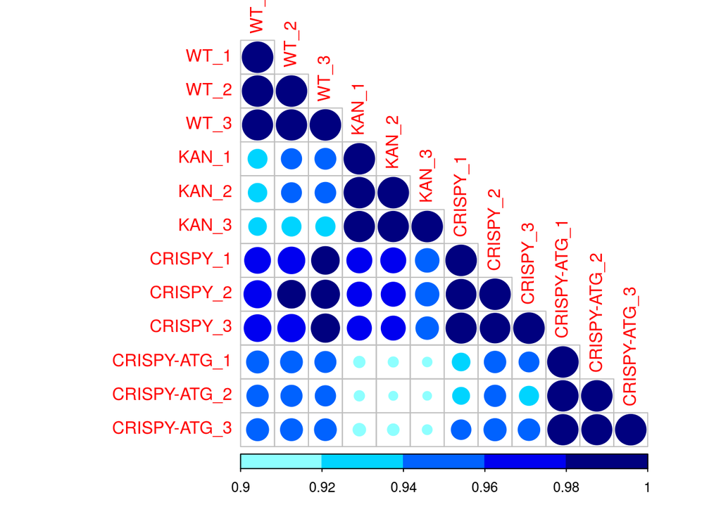

# Normalizing counts using DESeq2

```r
##### FILTER SAMPLES (OPTIONAL)
cnts <- cnts[,colnames(cnts) %in% coldata$sample[coldata$name %in% c("WT","CRISPY")]]
coldata <- coldata[coldata$name %in% c("WT","CRISPY"),]

dds <- DESeqDataSetFromMatrix(countData = as.matrix(cnts),
                       colData = coldata,
                       design = ~name)
dds <- DESeq(dds)
```

Since tools for differential expression analysis are comparing the counts between sample groups for the same gene, gene length does not need to be accounted for by DESeq.

## Sample Distances

To ensure there is roughly equal contribution from all genes, I use it on the VST data.

- This function calculates a variance stabilizing transformation (VST) from the fitted dispersion-mean relation(s) and then transforms the count data (normalized by division by the size factors), yielding a matrix of values which are now approximately homoskedastic (having constant variance along the range of mean values). The transformation also normalizes with respect to library size

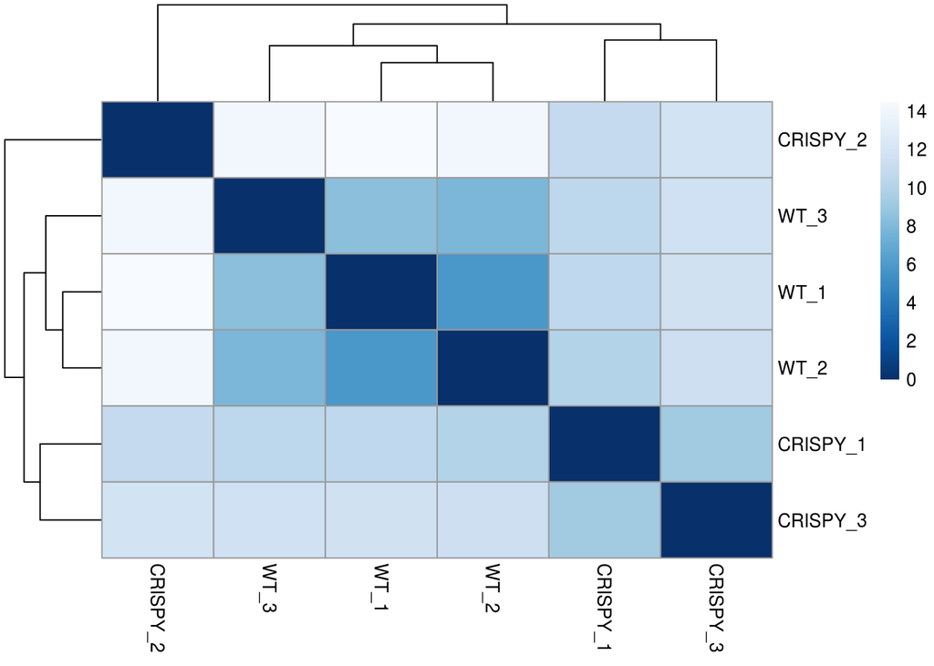

```r
vsd <- vst(dds)
sampleDists <- dist(t(assay(vsd)))
# cor(assay(vsd), method = 'pearson')

sampleDistMatrix <- as.matrix( sampleDists )
colors <- colorRampPalette( rev(brewer.pal(9, "Blues")) )(255)
pheatmap(sampleDistMatrix,
         clustering_distance_rows = sampleDists,
         clustering_distance_cols = sampleDists,
         col = colors,
         show_rownames = T,
         show_colnames = T)
```

## Principal Component Analysis (PCA)

PCA is another way to visualize sample-to-sample distances.

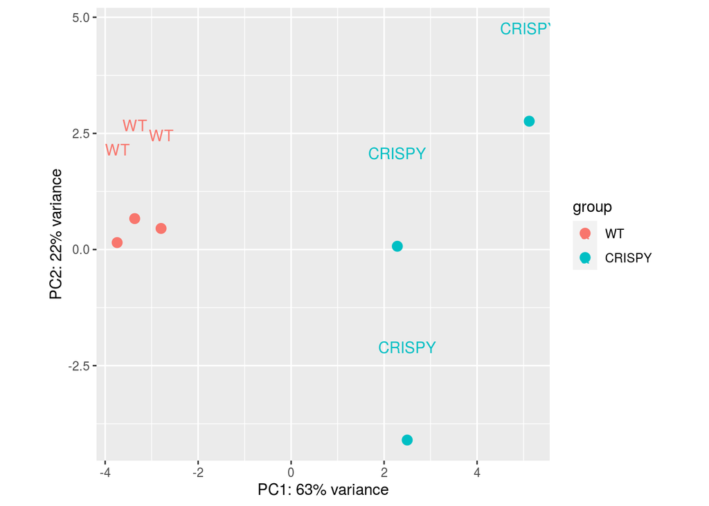

```r
plotPCA(vsd, intgroup = c("name")) +
  geom_text(aes(label = name), position = position_nudge(y = 2))
```

# Top Variable Genes

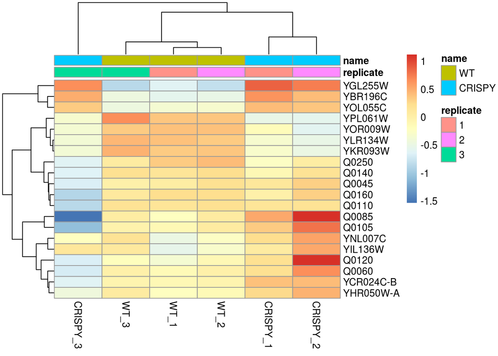

```r
topVarGenes <- head(order(rowVars(assay(vsd)), decreasing = TRUE), 20)

mat  <- assay(vsd)[ topVarGenes, ]
mat  <- mat - rowMeans(mat)
anno <- as.data.frame(colData(vsd)[,c("replicate","name")])
pheatmap(mat, annotation_col = anno)
```

These are the top variable genes, ie. have the highest variance. Which is not the same as top differentially expressed genes. This is just a good way of visualizing the data and seeing if the samples are clustering as expected.

# Differential Expression Analysis

```
## Processing CRISPY_vs_WT...
```

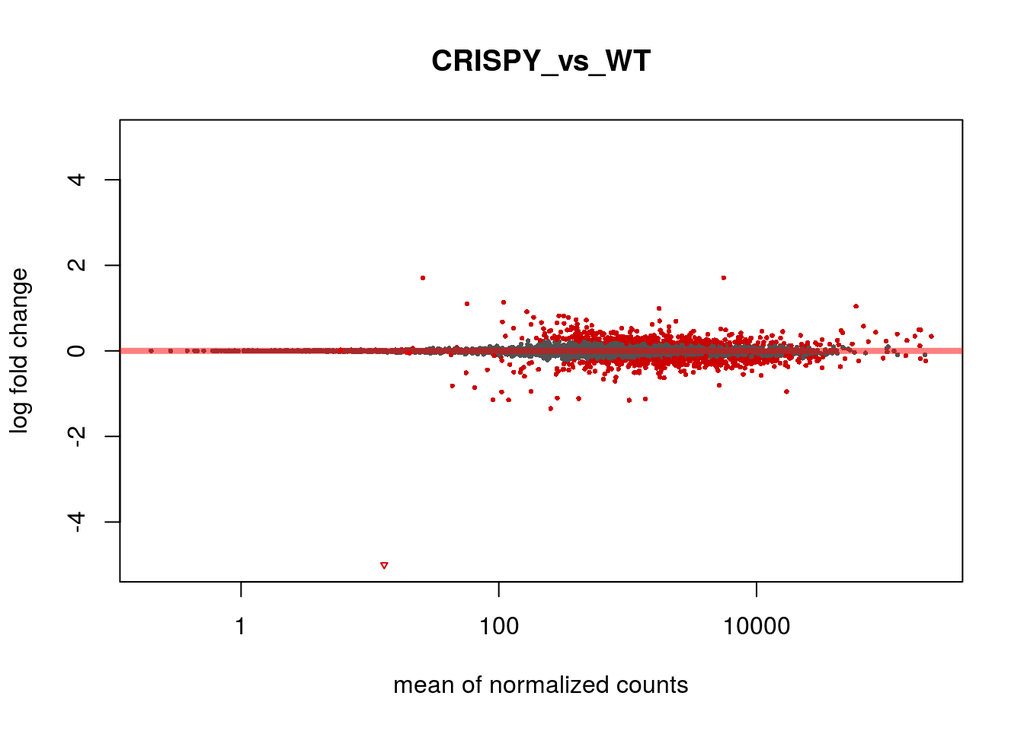

```
## When comparing CRISPY_vs_WT there are 13 genes with more than 1 log fold change at FDR of 5%. With 5 upregulated and 8 downregulated.
```

- YHR079C (IRE1)
- YFL031W (HAC1/ERN4/IRE15)
- YJL095W (BCK1/LAS3/SAP3/SLK1/SSP31)

## GO Term & KEGG Pathway Enrichment

Up- and down-regulated DEGs are used for GO term and KEGG pathway enrichment. P-value cut-off of 0.05 and false discovery rate of 5% (BH procedure) was used to consider enrichment.

```
## Processing CRISPY_vs_WT...
##
## There are no GO term enrichment for down-regulated DEGs in CRISPY_vs_WT.
##
## There are no KEGG pathway enriched for down-regulated DEGs in CRISPY_vs_WT.
##
## Top 5 GO term enrichment of up-regulated DEGs in CRISPY_vs_WT for:
##  1. Cellular component - .
##  2. Biological process - .
##  3. Molecular function - metal ion transmembrane transporter activity, inorganic cation transmembrane transporter activity, cation transmembrane transporter activity, divalent inorganic cation transmembrane transporter activity, potassium ion transmembrane transporter activity.
##
## Top 10 KEGG pathway enrichment for up-regulated DEGs in CRISPY_vs_WT are:
## Pentose phosphate pathway, Amino sugar and nucleotide sugar metabolism, Starch and sucrose metabolism, Glycolysis / Gluconeogenesis.
##
## Finished processing CRISPY_vs_WT.
##
## ----------
```